# Young water fraction estimation

## 4. Effect of sampling frequency

### 4.1 Data processing and scenarios

From the original data (daily data with missing). We used linear interpolation to get continuous daily data (without missing). This interpolation technique is applied to precipitation, streamflow, and isotope in precipitation and streamflow.

```r
# Interpolate to have daily data
isotopePinter <- list()
isotopeSinter <- list()

# Loop over the catchment
for (icatchment in 1:2){ # 1 = alph, 2 = Erlenbach

  # Get daily continuous isotope data in precipitation
  dateNumeric <- as.numeric(isotopeP[[icatchment]]$date)
  dateInter <- c(dateNumeric[1]:dateNumeric[length(dateNumeric)])
  isotopePinter[[icatchment]] <- tibble(
    date = as.Date(dateInter),
    water_flux_mm = approx(dateNumeric,
                           isotopeP[[icatchment]]$water_flux_mm,
                           xout = dateInter,
                           method = "linear")$y,
    delta_18O = approx(dateNumeric,
                       isotopeP[[icatchment]]$delta_18O,
                       xout = dateInter,
                       method = "linear")$y)

  # Get daily continuous isotope data in streamflow
  dateNumeric <- as.numeric(isotopeS[[icatchment]]$date)
  dateInter <- c(dateNumeric[1]:dateNumeric[length(dateNumeric)])
  isotopeSinter[[icatchment]] <- tibble(
    date = as.Date(dateInter),
    water_flux_mm = approx(dateNumeric,
                           isotopeS[[icatchment]]$water_flux_mm,
                           xout = dateInter,
                           method = "linear")$y,
    delta_18O = approx(dateNumeric,
                       isotopeS[[icatchment]]$delta_18O,
                       xout = dateInter,
                       method = "linear")$y)
}

# Now prepare weekly and monthly data
dateInterval <- c(1, 7, 14, 30)
isotopeInter <- list()

for (icatchment in 1:2){

  # Results as list object
  isotopeInter$catchment[[icatchment]] <- list()

  for (j in 1:length(dateInterval)){
    # find commonly date of P and S data
    isotopeInter$catchment[[icatchment]]$dateInterVal[[j]] <- list()

    # Precipitation
    commonDate <- as.Date(intersect(isotopePinter[[icatchment]]$date,
                                    isotopeSinter[[icatchment]]$date))

    commonDate <- seq(from = commonDate[2],
                      to = commonDate[length(commonDate)],
                      by = dateInterval[j])

    icommonDate <- which(isotopePinter[[icatchment]]$date %in% commonDate)
    isotopeInter$catchment[[icatchment]]$dateInterVal[[j]]$P <- isotopePinter[[icatchment]][icommonDate,]

    # Streamflow
    icommonDate <- which(isotopeSinter[[icatchment]]$date %in% commonDate)
    isotopeInter$catchment[[icatchment]]$dateInterVal[[j]]$S <- isotopeSinter[[icatchment]][icommonDate,]
  }
}
```

Plot to see the original and interpolated data at different time intervals (e.g., for the Alp catchment)

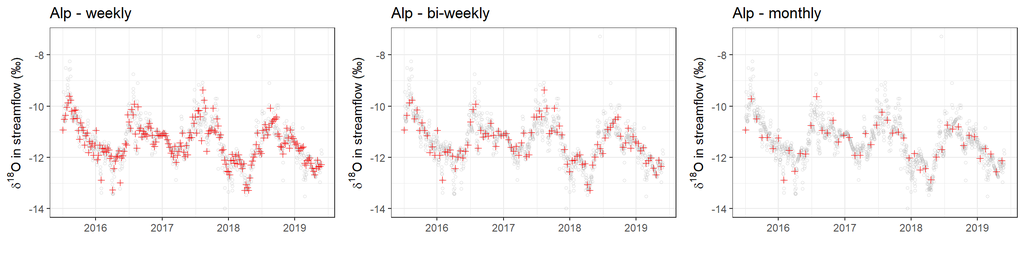

```r
# This is and example of plot for daily and monthly sampling interval for instream isotope
plt <- list()
samplingInterval <- c("Alp - daily", "Alp - weekly", "Alp - bi-weekly", "Alp - monthly")
for (i in 1:4){
  plt[[i]] <- ggplot()+
    geom_point(data = isotopeInter$catchment[[1]]$dateInterVal[[1]]$S,
               aes(x = date,
                   y = delta_18O,
                   color = "daily sampling"),
               shape = 1,
               size = 1,
               alpha = 0.5)+
    geom_point(data = isotopeInter$catchment[[1]]$dateInterVal[[i]]$S,
               aes(x = date,
                   y = delta_18O,
                   color = "monthly sampling"),
               shape = 3,
               alpha = 1)+
    scale_color_manual(values = c("daily sampling" = "gray",
                                  "monthly sampling" = "red"),
                       guide = guide_legend(override.aes = list(shape = c(1, 3))))+
    labs(x = "",
         y = expression(paste(delta^{18}, "O in streamflow (‰)")),
         title = samplingInterval[i],
         color = "")+
    theme_bw() +
    theme(legend.position = "none")
}


ggarrange(plt[[2]], plt[[3]], plt[[4]], ncol = 3, nrow = 1)
```

### 4.2 Find Fyw

```r
for (icatchment in 1:2){

  # Loop over number of date interval
  for (j in 1:length(dateInterval)){

    # Fit sine wave to P observed data
    isotope_P <- isotopeInter$catchment[[icatchment]]$dateInterVal[[j]]$P
    isotope_S <- isotopeInter$catchment[[icatchment]]$dateInterVal[[j]]$S

    # convert date to decimal
    tP <- decimal_date(isotope_P$date) - trunc(decimal_date(isotope_P$date))
    tS <- decimal_date(isotope_S$date) - trunc(decimal_date(isotope_S$date))

    # Fit to sine wave to observed isotope data in precipitation
    fitSineP <- fitSineNL(observed = isotope_P$delta_18O,
                          a = c(1,3),
                          phi = c(0, 2*pi),
                          k = c(-12,-8),
                          t = isotope_P$date,
                          nIter = 100000,
                          nBestIter = 100,
                          weight = isotope_P$water_flux_mm,
                          setSeed = 2023)

    # Fit Gamma using observed instream isotope composition
    simC <- fitGamma(AP = fitSineP$parameter$a,
                     phiP = fitSineP$parameter$phi,
                     kP = fitSineP$parameter$k,
                     alphaRange = c(0.01,5),
                     betaRange = c(0.01,5),
                     simulatedDate = isotope_S$date,
                     fittedData = isotope_S$delta_18O,
                     weight = isotope_S$water_flux_mm,
                     nIter = 100000,
                     nBestIter = 100,
                     nCores =100,
                     nWarmupYears = 10,
                     setSeed = 2023)

    # Save data
    isotopeInter$catchment[[icatchment]]$dateInterVal[[j]]$fitSineP <- fitSineP
    isotopeInter$catchment[[icatchment]]$dateInterVal[[j]]$simC <- simC
  }
}
```

Plot the estimated young water fractions for the Alp and Erlenbach catchments

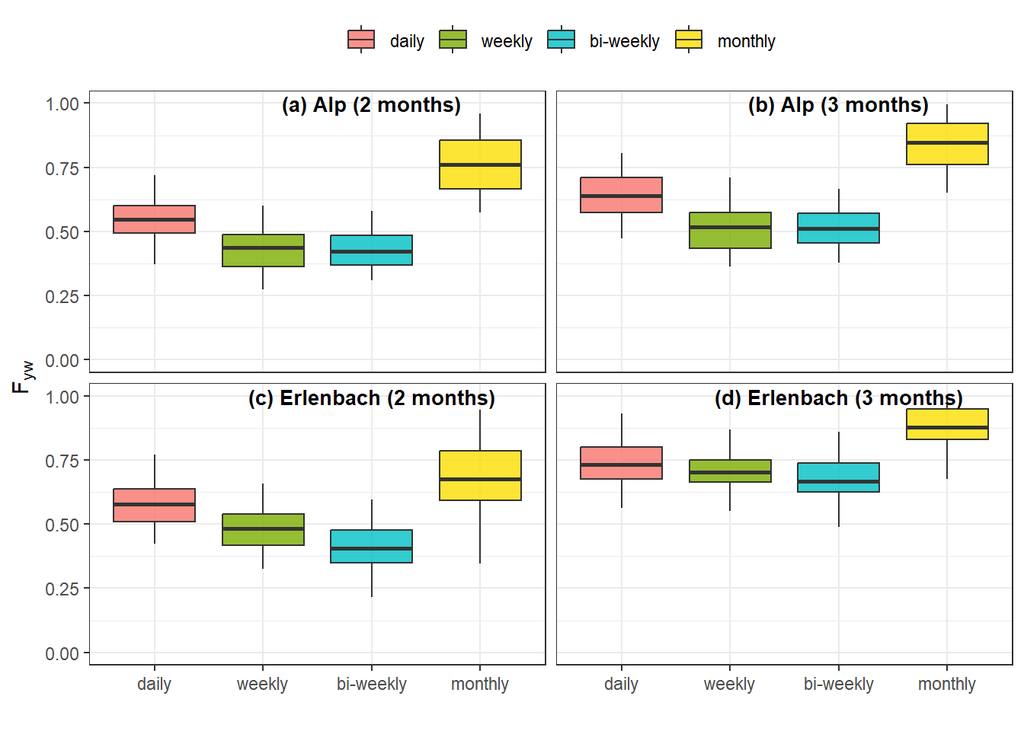

```r
# Load data (if users does not run the model)
load("data/isotopeInter.rda")

# Calculate Fyw
for (icatchment in 1:2){

  # Loop over number of date interval
  for (j in 1:4){
    parameter <- isotopeInter$catchment[[icatchment]]$dateInterVal[[j]]$simC$parameterSet

    for (sim in 1:100){
      temp <- tibble::tibble(Fyw = pgamma(c(2/12, 3/12),
                                          shape = parameter$alpha[sim],
                                          scale = parameter$beta[sim],
                                          lower.tail = TRUE),
                             catchment = icatchment,
                             timeStep = j,
                             tau  = c(2,3))

      if (icatchment + j + sim == 3){
        Fywater <- temp
      } else {
        Fywater <- rbind(Fywater, temp)
      }
    }
  }

}

# Create annotate Text
annoText <- data.frame(Fyw = c(rep(1,4)),
                       timeStep = rep(3,4),
                       catchment = c(1,1,2,2),
                       tau = c(2,3,2,3),
                       label = c("(a) Alp (2 months)",
                                 "(b) Alp (3 months)",
                                 "(c) Erlenbach (2 months)",
                                 "(d) Erlenbach (3 months)"))

# Plot Fyw
ggplot(Fywater)+
  geom_boxplot(aes(x = timeStep,
                   y = Fyw,
                   group = timeStep,
                   fill = as.character(timeStep)),
               alpha = 0.8)+
  facet_wrap(~ catchment + tau, ncol = 2)+
  scale_x_discrete(limits=c("#f8766d", "#7cae00", "#00bfc4", "#fcdf03"),
                   labels=c("daily", "weekly", "bi-weekly", "monthly")) +
  scale_fill_manual(name = " ",
                    labels = c("daily", "weekly", "bi-weekly", "monthly"),
                    values = c("#f8766d", "#7cae00", "#00bfc4", "#fcdf03"))+
  labs(x = "",
       y = expression(F[yw])) +
  theme_bw()+ ylim(0,1) +
  theme(legend.position = "top",
        strip.text.x = element_blank()) +
  geom_text(data = annoText,
            aes(x = timeStep,
                y = Fyw,
                label = label,
                fontface = "bold"),
            size = 3.5)
```

## 5. Supplement code for figures

```r
# Load function for ploting figures 1 to 5
source('R/plotFig1.R')
source('R/plotFig2.R')
source('R/plotFig3.R')
source('R/plotFig4.R')
source('R/plotFig5.R')

# Plot figure 1 to 5
figure1 <- plotFig1(isotopeData)
figure2 <- plotFig2(isotopeP, isotopeS, traditionalProcedure, revisedProcedure)
figure3 <- plotFig3(revisedProcedure, traditionalProcedure)
figure4 <- plotFig4(Fywater)
figure5 <- plotFig5(isotopeInter)

# NOTE: figure3 was subjected to minor edits using Inkscape (https://inkscape.org/)
```

### References

Freyberg, Jana von, Andrea Rücker, Massimiliano Zappa, Alessandro Schlumpf, Bjørn Studer, and James W Kirchner. 2022. “Four Years of Daily Stable Water Isotope Data in Stream Water and Precipitation from Three Swiss Catchments.” *Scientific Data* 9: 46. https://doi.org/10.1038/s41597-022-01148-1.

Kirchner, J. W. 2016. “Aggregation in Environmental Systems – Part 1: Seasonal Tracer Cycles Quantify Young Water Fractions, but Not Mean Transit Times, in Spatially Heterogeneous Catchments.” *Hydrology and Earth System Sciences* 20 (1): 279–97. https://doi.org/10.5194/hess-20-279-2016.